# CSB Data Analysis Template

This notebook performs data analysis and exploration on processed Crop Sequence Boundaries (CSB) data. It is designed to be a general template that works with CSB data from different time periods (e.g., 2009-2016, 2017-2024).

```python
# Import necessary libraries
#%pip install geopandas seaborn shapely numpy matplotlib pyarrow statsmodels
import pandas as pd
import geopandas as gpd
import matplotlib.pyplot as plt
import seaborn as sns
from shapely.wkt import loads
import numpy as np
import pyarrow
from statsmodels.tsa.stattools import acf, adfuller
import os

# Ensure plots display inline
%matplotlib inline
```

```python
# --- Configuration ---
# Set the years for the data you want to analyze
# These must match the years used in the download/transform step
START_YEAR = 2009
END_YEAR = 2016

# Base data directory
DATA_DIR = "data"

# Construct paths dynamically
folder_name = f"csb_{START_YEAR}{END_YEAR}"
file_name = f"ny_csb.feather_{START_YEAR}{END_YEAR}"
file_path = os.path.join(DATA_DIR, folder_name, file_name)

print(f"Configured to analyze data from: {START_YEAR} to {END_YEAR}")
print(f"Reading file: {file_path}")
```

```
Configured to analyze data from: 2009 to 2016
Reading file: data/csb_20092016/ny_csb.feather_20092016
```

## 1. Load Data

We load the dataset from the Feather file format, which is optimized for speed. We then inspect the structure, data types, and summary statistics.

```python
# Load data using pandas with a pyarrow fallback for feather files that require Arrow extensions
try:
    df = pd.read_feather(file_path)
    print("Data loaded successfully using pandas.read_feather().")
except Exception as e:
    # Common issue: missing/incorrect pyarrow installation or Arrow extension types
    print(f"Error loading data with pandas.read_feather: {e}")
    try:
        # Try reading with pyarrow directly as a fallback
        import pyarrow.feather as feather
        print("Attempting to read with pyarrow.feather.read_table()...")
        table = feather.read_table(file_path)
        # Convert to pandas DataFrame
        try:
            df = table.to_pandas()
        except Exception:
            # If conversion with default options fails, try without threads
            df = table.to_pandas(use_threads=False)
        print("Data loaded successfully using pyarrow.")
    except ImportError:
        print("pyarrow is not installed. Install it with `pip install pyarrow` or use conda (`conda install -c conda-forge pyarrow`) and restart the kernel.")
        raise
    except Exception as e2:
        print(f"pyarrow failed to read the file: {e2}")
        raise

# Inspect the first few rows to understand the data structure
print("\nFirst 5 rows:")
display(df.head())

# Inspect column data types and non-null counts
print("\nDataFrame Info:")
df.info()

# Summary statistics for numerical columns
print("\nStatistical Description:")
display(df.describe())
```

```
Data loaded successfully using pandas.read_feather().

First 5 rows:
```

|  | CSBID | CSBYEARS | CSBACRES | CDL2009 | CDL2010 | CDL2011 | CDL2012 | CDL2013 | CDL2014 | CDL2015 | ... | STATEFIPS | STATEASD | ASD | CNTY | CNTYFIPS | INSIDE_X | INSIDE_Y | Shape_Length | Shape_Area | geometry |
| --- | --- | --- | --- | --- | --- | --- | --- | --- | --- | --- | --- | --- | --- | --- | --- | --- | --- | --- | --- | --- | --- |
| 1095234 | 36916001095235 | 916 | 4.512908 | 176 | 36 | 36 | 1 | 176 | 176 | 36 | ... | 36 | 3630 | 30 | Clinton | 019 | 1.757629e+06 | 2.621813e+06 | 695.822186 | 18263.088835 | b'\x01\x06\x00\x00\x00\x01\x00\x00\x00\x01\x03... |
| 1095235 | 36916001095236 | 916 | 3.055459 | 124 | 1 | 37 | 1 | 176 | 61 | 1 | ... | 36 | 3630 | 30 | Clinton | 019 | 1.756961e+06 | 2.621583e+06 | 456.464290 | 12365.004290 | b'\x01\x06\x00\x00\x00\x01\x00\x00\x00\x01\x03... |
| 1095236 | 36916001095237 | 916 | 7.243785 | 1 | 36 | 36 | 37 | 36 | 37 | 36 | ... | 36 | 3630 | 30 | Clinton | 019 | 1.758870e+06 | 2.621846e+06 | 906.126858 | 29314.558303 | b'\x01\x06\x00\x00\x00\x01\x00\x00\x00\x01\x03... |
| 1095237 | 36916001095238 | 916 | 3.758001 | 1 | 1 | 37 | 1 | 176 | 36 | 1 | ... | 36 | 3630 | 30 | Clinton | 019 | 1.757304e+06 | 2.621414e+06 | 658.110322 | 15208.089962 | b'\x01\x06\x00\x00\x00\x01\x00\x00\x00\x01\x03... |
| 1095238 | 36916001095239 | 916 | 3.415562 | 1 | 36 | 37 | 1 | 176 | 36 | 1 | ... | 36 | 3630 | 30 | Clinton | 019 | 1.757451e+06 | 2.621454e+06 | 686.692344 | 13822.290443 | b'\x01\x06\x00\x00\x00\x01\x00\x00\x00\x01\x03... |

5 rows × 21 columns

```
DataFrame Info:
<class 'pandas.DataFrame'>
Index: 569138 entries, 1095234 to 19696982
Data columns (total 21 columns):
 #   Column        Non-Null Count   Dtype
---  ------        --------------   -----
 0   CSBID         569138 non-null  str
 1   CSBYEARS      569138 non-null  str
 2   CSBACRES      569138 non-null  float64
 3   CDL2009       569138 non-null  int32
 4   CDL2010       569138 non-null  int32
 5   CDL2011       569138 non-null  int32
 6   CDL2012       569138 non-null  int32
 7   CDL2013       569138 non-null  int32
 8   CDL2014       569138 non-null  int32
 9   CDL2015       569138 non-null  int32
 10  CDL2016       569138 non-null  int32
 11  STATEFIPS     569138 non-null  str
 12  STATEASD      569138 non-null  str
 13  ASD           569138 non-null  str
 14  CNTY          569138 non-null  str
 15  CNTYFIPS      569138 non-null  str
 16  INSIDE_X      569138 non-null  float64
 17  INSIDE_Y      569138 non-null  float64
 18  Shape_Length  569138 non-null  float64
 19  Shape_Area    569138 non-null  float64
 20  geometry      569138 non-null  object
dtypes: float64(5), int32(8), object(1), str(7)
memory usage: 97.5+ MB

Statistical Description:
```

|  | CSBACRES | CDL2009 | CDL2010 | CDL2011 | CDL2012 | CDL2013 | CDL2014 | CDL2015 | CDL2016 | INSIDE_X | INSIDE_Y | Shape_Length | Shape_Area |
| --- | --- | --- | --- | --- | --- | --- | --- | --- | --- | --- | --- | --- | --- |
| count | 569138.000000 | 569138.000000 | 569138.000000 | 569138.000000 | 569138.000000 | 569138.000000 | 569138.000000 | 569138.000000 | 569138.000000 | 5.691380e+05 | 5.691380e+05 | 569138.000000 | 5.691380e+05 |
| mean | 8.497931 | 82.390963 | 37.593074 | 43.281181 | 39.904779 | 83.760705 | 78.785430 | 63.028826 | 63.982266 | 1.596137e+06 | 2.376269e+06 | 847.323024 | 3.438993e+04 |
| std | 10.976421 | 75.014900 | 36.820487 | 46.212314 | 43.445441 | 75.355720 | 73.359964 | 65.184660 | 66.042969 | 1.323226e+05 | 8.939366e+04 | 525.360799 | 4.442002e+04 |
| min | 1.772742 | 1.000000 | 1.000000 | 0.000000 | 1.000000 | 1.000000 | 1.000000 | 1.000000 | 0.000000 | 1.324355e+06 | 2.166972e+06 | 342.711687 | 7.174034e+03 |
| 25% | 3.353061 | 28.000000 | 36.000000 | 24.000000 | 5.000000 | 36.000000 | 36.000000 | 24.000000 | 24.000000 | 1.492445e+06 | 2.315519e+06 | 531.731386 | 1.356936e+04 |
| 50% | 4.481143 | 37.000000 | 37.000000 | 37.000000 | 37.000000 | 37.000000 | 37.000000 | 37.000000 | 37.000000 | 1.595737e+06 | 2.362906e+06 | 639.695498 | 1.813454e+04 |
| 75% | 8.219294 | 176.000000 | 37.000000 | 37.000000 | 37.000000 | 176.000000 | 176.000000 | 69.000000 | 121.000000 | 1.698815e+06 | 2.407898e+06 | 945.818746 | 3.326230e+04 |
| max | 669.591165 | 244.000000 | 250.000000 | 250.000000 | 243.000000 | 254.000000 | 254.000000 | 254.000000 | 244.000000 | 1.988381e+06 | 2.657851e+06 | 16212.064066 | 2.709739e+06 |

### Statistical Summary & Insights

The code below calculates robust statistics for field sizes and checks for outliers. This helps understand the distribution of agricultural field sizes in the dataset.

```python
# robust summaries
import numpy as np
from scipy.stats import skew

if 'CSBACRES' in df.columns:
    x = df['CSBACRES'].dropna()
    mean = x.mean()
    median = x.median()
    trimmed_mean = x.clip(upper=x.quantile(0.99)).mean()   # 99% winsorized mean
    geom_mean = np.expm1(np.log1p(x).mean())               # geometric mean (back-transformed)

    print(f"Count: {len(x):,}")
    print(f"Mean: {mean:.2f} acres, Median: {median:.2f} acres")
    print(f"99% winsorized mean: {trimmed_mean:.2f} acres")
    print(f"Geometric mean (exp(mean(log1p))-1): {geom_mean:.2f} acres")

    # Check skew and compare raw vs log1p
    print("Skewness (raw):", round(skew(x), 3))
    print("Skewness (log1p):", round(skew(np.log1p(x)), 3))

    # Example: classify for mapping (quantiles on log scale)
    df['log_acres'] = np.log1p(df['CSBACRES'])
    df['log_quartile'] = pd.qcut(df['log_acres'], 5, labels=False)
else:
    print("Column 'CSBACRES' not found.")
```

```
Count: 569,138
Mean: 8.50 acres, Median: 4.48 acres
99% winsorized mean: 8.25 acres
Geometric mean (exp(mean(log1p))-1): 6.05 acres
Skewness (raw): 6.927
Skewness (log1p): 1.352
```

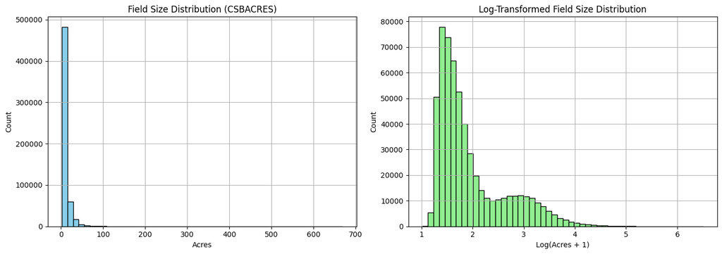

```
Top Crop Types in CDL2016 (Counts):
```

|  | Crop | Count |
| --- | --- | --- |
| 0 | Other Hay | 184918 |
| 1 | Grass/Pasture | 129897 |
| 2 | Corn | 105634 |
| 3 | Alfalfa | 65963 |
| 4 | Soybeans | 27247 |
| 5 | Code 61 | 11152 |
| 6 | Code 24 | 8989 |
| 7 | Code 141 | 6593 |
| 8 | Code 68 | 4191 |
| 9 | Code 28 | 3895 |

```
Total Acreage by County (Top 10 Counties) based on CDL2016:
```

| CNTY | Total Acres |
| --- | --- |
| Jefferson | 248253.443008 |
| St. Lawrence | 213081.002971 |
| Steuben | 200532.939883 |
| Cayuga | 186938.180530 |
| Livingston | 173884.773379 |
| Chautauqua | 158104.883864 |
| Wyoming | 157392.261565 |
| Ontario | 155156.021546 |
| Genesee | 148504.738189 |
| Oneida | 136420.991790 |

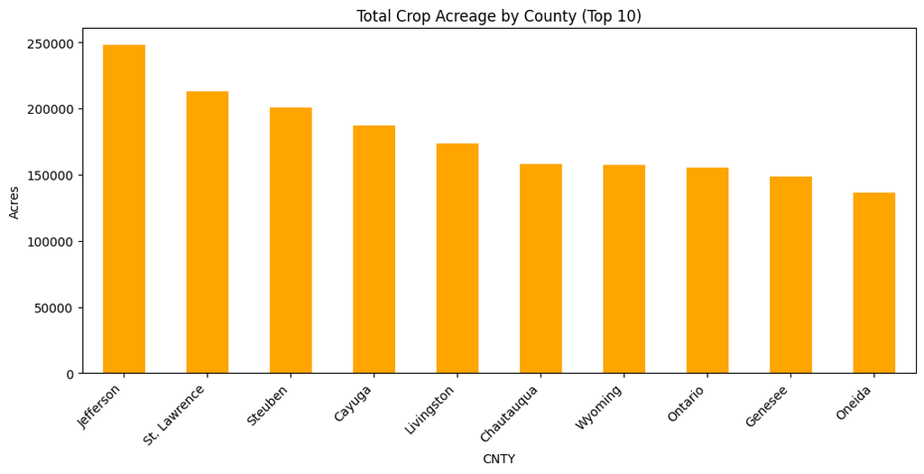

```python
# --- Suggested Visual Checks & Analyses ---

# 1. Field Size Distribution (Histogram)
if 'CSBACRES' in df.columns:
    plt.figure(figsize=(14, 5))
    plt.subplot(1, 2, 1)
    df['CSBACRES'].hist(bins=50, color='skyblue', edgecolor='black')
    plt.title('Field Size Distribution (CSBACRES)')
    plt.xlabel('Acres')
    plt.ylabel('Count')

    plt.subplot(1, 2, 2)
    np.log1p(df['CSBACRES']).hist(bins=50, color='lightgreen', edgecolor='black')
    plt.title('Log-Transformed Field Size Distribution')
    plt.xlabel('Log(Acres + 1)')
    plt.ylabel('Count')
    plt.tight_layout()
    plt.show()

# 2. Crop Frequency Table (Top Crops in the most recent year)
# Dynamically find the last available year column
cdl_cols = [col for col in df.columns if col.startswith('CDL') and col[3:].isdigit()]
if cdl_cols:
    last_year_col = sorted(cdl_cols)[-1]
    print(f"\nTop Crop Types in {last_year_col} (Counts):")

    # Simple mapping for quick check
    quick_map = {1: 'Corn', 5: 'Soybeans', 36: 'Alfalfa', 37: 'Other Hay', 176: 'Grass/Pasture'}

    counts_last_year = df[last_year_col].value_counts().head(10).rename("Count")
    names_last_year = counts_last_year.index.map(lambda x: quick_map.get(x, f"Code {x}"))
    freq_table = pd.DataFrame({'Crop': names_last_year, 'Count': counts_last_year.values})
    display(freq_table)

    # 3. Regional Analysis (Acreage by County for top crops)
    if 'CNTY' in df.columns:
        print(f"\nTotal Acreage by County (Top 10 Counties) based on {last_year_col}:")
        county_acres = df.groupby('CNTY')['CSBACRES'].sum().sort_values(ascending=False).head(10)
        display(county_acres.to_frame(name="Total Acres"))

        plt.figure(figsize=(12, 5))
        county_acres.plot(kind='bar', color='orange')
        plt.title("Total Crop Acreage by County (Top 10)")
        plt.ylabel("Acres")
        plt.xticks(rotation=45, ha='right')
        plt.show()
```

## 2. Geometry Exploration

```
Parsing geometry column to shapely objects (this may take some time)...
GeoDataFrame created.
Plotting sample of data...
```

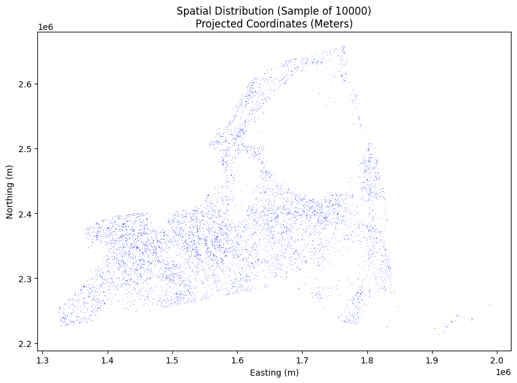

```python
# Check if 'geometry' column exists
if 'geometry' in df.columns:
    # Examine first entry to detect format: WKT (str), WKB (bytes) or bytes-as-string
    first_geom = df['geometry'].iloc[0]

    # Prepare a column of shapely geometries named 'geom'
    from shapely.wkb import loads as wkb_loads
    from shapely.wkt import loads as wkt_loads
    import ast
    from shapely.geometry.base import BaseGeometry

    def parse_geom(val):
        # bytes (WKB)
        if isinstance(val, (bytes, bytearray)):
            return wkb_loads(val)
        # string: try WKT first
        if isinstance(val, str):
            # common case: literal b'...' stored as string
            if val.startswith("b'") or val.startswith('b"'):
                try:
                    b = ast.literal_eval(val)
                    return wkb_loads(b)
                except Exception:
                    pass
            # try WKT
            try:
                return wkt_loads(val)
            except Exception:
                # try interpreting as utf-8 bytes then WKB
                try:
                    b = val.encode('utf-8')
                    return wkb_loads(b)
                except Exception:
                    raise
        # If it's already a shapely geometry, return as-is
        if isinstance(val, BaseGeometry):
            return val
        # Unknown format
        raise TypeError('Unsupported geometry format')

    # Apply parsing with safe error handling for large datasets
    print('Parsing geometry column to shapely objects (this may take some time)...')
    try:
        df['geom'] = df['geometry'].apply(lambda v: parse_geom(v))
    except Exception as e:
        # Attempt vectorized fallback: try using GeoPandas from_wkb if available
        print(f'Error parsing geometries with custom parser: {e}')
        try:
            # geopandas can read WKB via GeoSeries.from_wkb (pandas array of bytes)
            gpd_series = gpd.GeoSeries.from_wkb(df['geometry'])
            df['geom'] = gpd_series
        except Exception as e2:
            print(f'Fallback parsing also failed: {e2}')
            raise

    # Create a GeoDataFrame
    try:
        gdf = gpd.GeoDataFrame(df, geometry='geom')
    except Exception as e:
        print(f'Failed to create GeoDataFrame: {e}')
        raise

    print('GeoDataFrame created.')

    # Plot the spatial data (sample to avoid performance issues)
    print('Plotting sample of data...')
    sample_size = min(10000, len(gdf))

    # Plot customization for visibility:
    # - Increase marker size or use edge color for polygons
    # - Use alpha=1.0 for maximum visibility of thin lines
    # - Coordinates are projected (likely meters), not Lat/Lon
    gdf.sample(sample_size).plot(figsize=(10, 10), alpha=1.0, edgecolor='blue', linewidth=0.3)
    plt.title(f"Spatial Distribution (Sample of {sample_size})\nProjected Coordinates (Meters)")
    plt.xlabel('Easting (m)')
    plt.ylabel('Northing (m)')
    plt.show()
else:
    print("'geometry' column not found. Skipping spatial conversion.")
```

## 3. Spatial Analysis

We compute the area of each field. Note that for accurate area calculations in meters/feet, the CRS should be a projected system (e.g., Albers Equal Area). We also demonstrate how to filter the dataset, for example, selecting records specific to New York State.

```python
if 'gdf' in locals():
    # Calculate area
    # Warning: The unit depends on the CRS. If Lat/Lon (EPSG:4326), this is in degrees^2 (useless).
    # For accurate area, project to a planar CRS first, e.g., gdf.to_crs(epsg=5070).area
    gdf['area_calculated'] = gdf.area
    print("Area calculated (in CRS units).")
    display(gdf[['geometry', 'area_calculated']].head())

    # Filter for New York State
    # We check if a 'state' column exists and filter for 'NY' or check STATEFIPS
    if 'state' in gdf.columns:
        ny_data = gdf[gdf['state'] == 'NY']
        print(f"\nNumber of records in NY: {len(ny_data)}")
    elif 'STATEFIPS' in gdf.columns:
        # NY FIPS is 36
        ny_data = gdf[gdf['STATEFIPS'] == '36']
        print(f"\nNumber of records in NY (FIPS 36): {len(ny_data)}")
    else:
        print("\n'state' or 'STATEFIPS' column not found. Assuming dataset is already filtered.")
        ny_data = gdf
else:
    print("GeoDataFrame not available for spatial analysis.")
```

```
Area calculated (in CRS units).
```

|  | geometry | area_calculated |
| --- | --- | --- |
| 1095234 | b'\x01\x06\x00\x00\x00\x01\x00\x00\x00\x01\x03... | 18263.088835 |
| 1095235 | b'\x01\x06\x00\x00\x00\x01\x00\x00\x00\x01\x03... | 12365.004290 |
| 1095236 | b'\x01\x06\x00\x00\x00\x01\x00\x00\x00\x01\x03... | 29314.558303 |
| 1095237 | b'\x01\x06\x00\x00\x00\x01\x00\x00\x00\x01\x03... | 15208.089962 |
| 1095238 | b'\x01\x06\x00\x00\x00\x01\x00\x00\x00\x01\x03... | 13822.290443 |

```
Number of records in NY (FIPS 36): 569138
```

## 4. Other Data Exploration

We explore non-spatial attributes, such as crop sequences and temporal trends.

- **Crop Mapping:** Convert CDL codes to readable short names (e.g., 1 -> Corn).
- **Crop Sequence:** Classify crop rotation patterns into simplified categories (e.g., Continuous Corn, Rotation Corn-Soy).
- **Time Series Statistics:** Analyze crop stability over time using ACF and Unit Root tests (ADF).

```
Detected years: [2009, 2010, 2011, 2012, 2013, 2014, 2015, 2016]
Classifying crop sequences...

Top 10 Crop Rotations (Grouped Categories):
```

|  | Rotation Type | Count |
| --- | --- | --- |
| 0 | Rot Grs-Hay | 162465 |
| 1 | Complex/Mixed | 113642 |
| 2 | Rot Corn-Grs-Hay | 30026 |
| 3 | Cont. Hay | 29633 |
| 4 | Rot Alf-Grs-Hay | 26485 |
| 5 | Rot Alf-Corn | 22282 |
| 6 | Rot Alf-Corn-Hay | 18865 |
| 7 | Rot Corn-Soy | 16124 |
| 8 | Rot Corn-Hay | 15577 |
| 9 | Rot Alf-Hay | 13935 |

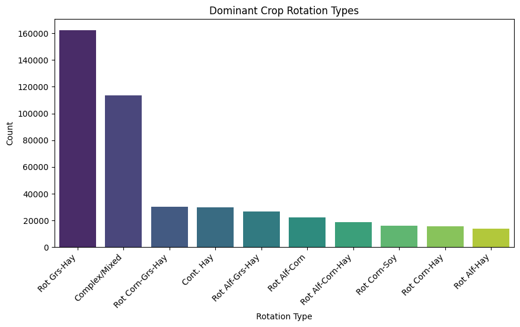

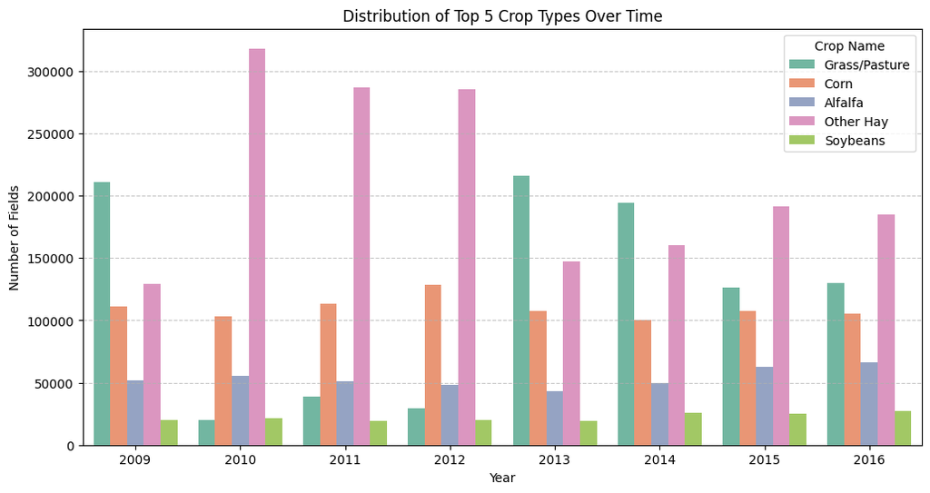

```
--- Time Series Statistical Metrics ---
```

|  | Crop | ACF (Lag 1) | ADF Statistic | P-Value | Stationary? |
| --- | --- | --- | --- | --- | --- |
| 0 | Other Hay | 0.128 | -1.820 | 0.3705 | False |
| 1 | Grass/Pasture | 0.112 | -2.233 | 0.1944 | False |
| 2 | Corn | 0.091 | -1.999 | 0.2871 | False |
| 3 | Alfalfa | 0.436 | -3.463 | 0.0090 | True |
| 4 | Soybeans | 0.391 | -0.966 | 0.7655 | False |

```
Note: High P-Value (>0.05) implies non-stationarity (trend/instability).
```

```python
# Define Short Crop Code Mapping for easier reading
# Source: USDA NASS Cropland Data Layer Metadata
cdl_short_mapping = {
    1: 'Corn',
    5: 'Soy',
    36: 'Alf',
    37: 'Hay',
    176: 'Grs',
    59: 'Sod',
    61: 'Fal',
    24: 'Wht',
    4: 'Sorg',
    121: 'Dev',
    122: 'Dev',
    111: 'Wtr',
    141: 'For',
    142: 'For',
    143: 'For',
    152: 'Shrb',
    190: 'Wet',
    195: 'Wet'
}

# Full mapping for plots
cdl_full_mapping = {
    1: 'Corn',
    5: 'Soybeans',
    36: 'Alfalfa',
    37: 'Other Hay',
    176: 'Grass/Pasture',
    59: 'Sod/Grass Seed',
    61: 'Fallow',
    24: 'Winter Wheat',
    121: 'Developed',
    141: 'Forest',
}

def get_short_name(code):
    return cdl_short_mapping.get(code, str(code))

# Detect CDL columns dynamically
cdl_cols = [col for col in df.columns if col.startswith('CDL') and col[3:].isdigit()]
year_cols = sorted([int(col[3:]) for col in cdl_cols])

print(f"Detected years: {year_cols}")

# 1. Group & Classify Crop Sequences
if cdl_cols:
    print("Classifying crop sequences...")

    # Get sequences as list of codes
    sequences = df[cdl_cols].values

    def classify_rotation(seq):
        unique_crops = set(seq)
        unique_names = [get_short_name(c) for c in unique_crops]

        # 1. Continuous (Single crop dominant)
        # Allow 1-2 years of "noise" or slight deviation in long series if needed, but strictly:
        if len(unique_crops) == 1:
            return f"Cont. {unique_names[0]}"

        # 2. Simple Rotation (Two crops)
        if len(unique_crops) == 2:
            crops_str = "-".join(sorted(unique_names))
            return f"Rot {crops_str}"

        # 3. Three Crop Rotation
        if len(unique_crops) == 3:
             # Prioritize common ones like Corn-Soy-Wht
             crops_str = "-".join(sorted(unique_names))
             return f"Rot {crops_str}"

        # 4. Complex
        return "Complex/Mixed"

    # Apply classification
    df['Rotation_Type'] = [classify_rotation(row) for row in sequences]

    # Count rotation types
    rotation_counts = df['Rotation_Type'].value_counts().head(10)

    print("\nTop 10 Crop Rotations (Grouped Categories):")
    rot_df = rotation_counts.reset_index()
    rot_df.columns = ['Rotation Type', 'Count']
    display(rot_df)

    plt.figure(figsize=(10, 5))
    sns.barplot(data=rot_df, x='Rotation Type', y='Count', palette='viridis', hue='Rotation Type', legend=False)
    plt.title("Dominant Crop Rotation Types")
    plt.xticks(rotation=45, ha='right')
    plt.show()

# 2. Time Series Analysis
if cdl_cols:
    # Melt to long format
    melted = df[cdl_cols].melt(var_name='Year_Col', value_name='Crop_Code')
    melted['Year'] = melted['Year_Col'].str.replace('CDL', '').astype(int)

    # Map codes to FULL names for plot legend
    melted['Crop_Name'] = melted['Crop_Code'].map(cdl_full_mapping).fillna(melted['Crop_Code'].astype(str))

    # Filter for top 5 crops
    top_crops_names = melted['Crop_Name'].value_counts().head(5).index
    filtered_melted = melted[melted['Crop_Name'].isin(top_crops_names)]

    plt.figure(figsize=(12, 6))
    sns.countplot(data=filtered_melted, x='Year', hue='Crop_Name', palette='Set2')
    plt.title("Distribution of Top 5 Crop Types Over Time")
    plt.ylabel("Number of Fields")
    plt.xlabel("Year")
    plt.legend(title='Crop Name')
    plt.grid(axis='y', linestyle='--', alpha=0.7)
    plt.show()

    # --- Statistical Metrics (ACF, Unit Root) ---
    print("\n--- Time Series Statistical Metrics ---")

    # Aggregate counts per year for each major crop to create time series
    ts_data = melted.groupby(['Year', 'Crop_Name']).size().unstack(fill_value=0)

    stats_results = []

    for crop in top_crops_names:
        series = ts_data[crop]

        # 1. Autocorrelation (ACF) at lag 1
        acf_val = acf(series, nlags=1)[1] if len(series) > 1 else np.nan

        # 2. ADF Unit Root Test
        try:
            adf_result = adfuller(series)
            adf_stat = adf_result[0]
            p_value = adf_result[1]
            is_stationary = p_value < 0.05
        except Exception:
            adf_stat = np.nan
            p_value = np.nan
            is_stationary = "Error"

        stats_results.append({
            'Crop': crop,
            'ACF (Lag 1)': round(acf_val, 3),
            'ADF Statistic': round(adf_stat, 3),
            'P-Value': round(p_value, 4),
            'Stationary?': is_stationary
        })

    stats_df = pd.DataFrame(stats_results)
    display(stats_df)
    print("Note: High P-Value (>0.05) implies non-stationarity (trend/instability).")
```